# Разработка модели с целью определения возраста покупателей

Внедрение системы компьютерного зрения для обработки фотографий покупателей в прикассовой зоне с целью определения возраста клиентов - это спорная и неоднозначная практика, которую необходимо рассматривать с точки зрения этических, правовых и практических аспектов.

# Описание проекта

Гипермаркет внедряет систему компьютерного зрения для обработки фотографий покупателей. Фотофиксация в прикассовой зоне поможет определять возраст клиентов, чтобы:

- Анализировать покупки и предлагать товары, которые могут заинтересовать покупателей этой возрастной группы;
- Контролировать добросовестность кассиров при продаже алкоголя.

# Задача проекта

Постройть модель, которая по фотографии определит приблизительный возраст человека. В нашем распоряжении набор фотографий людей с указанием возраста.

# Шаги выполнения задачи

- Провести исследовательский анализ набора фотографий.
- Подготовить данные к обучению.
- Обучить нейронную сеть и рассчитать её качество.

## Исследовательский анализ данных

### Импортируем необходимые библиотеки

```python
import pandas as pd
import tensorflow as tf
from tensorflow.keras.preprocessing.image import ImageDataGenerator
import matplotlib.pyplot as plt
import seaborn as sns
import numpy as np

from PIL import Image
```

### Загрузим данные

```python
data = pd.read_csv('/datasets/faces/labels.csv')
datagen = ImageDataGenerator(rescale = 1./255)
datagen_flow = datagen.flow_from_dataframe(data,
                                           directory='/datasets/faces/final_files/',
                                           x_col='file_name',
                                           y_col='real_age',
                                           target_size=(224, 224),
                                           batch_size=32,
                                           class_mode='raw',
                                           seed=12345)
```

```
Found 7591 validated image filenames.
```

```python
data.info()
```

```
<class 'pandas.core.frame.DataFrame'>
RangeIndex: 7591 entries, 0 to 7590
Data columns (total 2 columns):
 #   Column     Non-Null Count  Dtype
---  ------     --------------  -----
 0   file_name  7591 non-null   object
 1   real_age   7591 non-null   int64
dtypes: int64(1), object(1)
memory usage: 118.7+ KB
```

### Построим график распределения данных

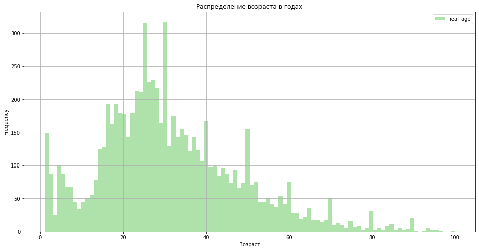

```python
fig, ax = plt.subplots()
ax.set_title('Распределение возраста в годах')
ax.set_xlabel('Возраст')
data.plot(kind='hist', bins=100, figsize=(16,8), color="#11aa0055", grid=True, ax=ax);
```

### Выведем из данных 12 фотографий

[figure not shown]

```python
features, target = next(datagen_flow)
fig = plt.figure(figsize=(14,14))
for i in range(12):
    fig.add_subplot(4, 4, i+1)
    plt.imshow(features[i])
    plt.xticks([])
    plt.yticks([])
    plt.tight_layout()
```

### Выводы по исследовательскому анализу данных

- Размерность датасета составляет 7591 объектов;
- По графику распределения данных, преобладают возраста от 18 до 40 лет. Стоит обратить внимание на возраст 0 лет и свыше 70 лет. В 0 лет график стремительно направлен вверх, это, скорее всего, обозначает лишь то, что родители своих малышей пытаются как можно чаще запечатлеть их в таком милом возрасте. Люди свыше 70 лет не так заинтересованы в фотосъемке, и стоит учесть, что это уже преклонный возраст, таких людей меньше, нежели людей в возрасте 50 лет, здесь прослеживается естественная убыль населения.
- По выведенным фотографиям стоит сразу отметить обрезанные фотографии, а также повернутые фотографии. Это может отобразиться на обучении и предсказании данных.

## Обучение модели

Обучим модель в GPU-тренажёре, для этого необходимо учесть следуюущие рекомендации:

- Функцией потерь не обязательно должна быть MAE. Зачастую нейронные сети с функцией потерь MSE обучаются быстрее.
- Обычно нейронные сети с большим числом слоёв сильно переобучаются.
- Проверить, что методы load_train(path) и load_test(path) корректно работают с данными. В папке path содержится csv-файл labels.csv с двумя колонками file_name и real_age и папка с изображениями /final_files. Необходимо прочитать данные из csv-файла labels.csv в датафрейм, который будет одним из параметров метода ImageDataGenerator —flow_from_dataframe(dataframe, directory, ...).

Перенесем сюда код обучения модели и её результат вывода на экран.

(Код в этом разделе запускается в отдельном GPU-тренажёре, поэтому оформлен не как ячейка с кодом, а как код в текстовой ячейке)

```
import numpy as np
import pandas as pd
from tensorflow.keras.datasets import fashion_mnist
from tensorflow.keras.layers import Conv2D, Flatten, AvgPool2D, Dense, GlobalAveragePooling2D
from tensorflow.keras.models import Sequential
from tensorflow.keras.optimizers import Adam
from tensorflow.keras.preprocessing.image import ImageDataGenerator
from tensorflow.keras.applications.resnet import ResNet50

def load_train(path):
    labels = pd.read_csv(path+'labels.csv')
    train_datagen = ImageDataGenerator(rescale= 1./255, horizontal_flip=True, validation_split=0.25)
    train_datagen_flow = train_datagen.flow_from_dataframe(
        dataframe = labels,
        directory = path + 'final_files/',
        x_col='file_name',
        y_col='real_age',
        target_size=(224, 224),
        batch_size=32,
        class_mode='raw',
        subset='training',
        seed=12345)
    return train_datagen_flow

def load_test(path):
    labels = pd.read_csv(path+'labels.csv')
    test_datagen = ImageDataGenerator(rescale= 1./255, validation_split=0.25)
    test_datagen_flow = test_datagen.flow_from_dataframe(
        dataframe = labels,
        directory = path + 'final_files/',
        x_col='file_name',
        y_col='real_age',
        target_size=(224, 224),
        batch_size=32,
        class_mode='raw',
        subset='validation',
        seed=12345)
    return test_datagen_flow

def create_model(input_shape):
    optimizer = Adam(lr=0.0001)
    backbone = ResNet50(input_shape= input_shape, weights='imagenet', include_top= False)
    model = Sequential()
    model.add(backbone)
    model.add(GlobalAveragePooling2D())
    model.add(Dense(1, activation='relu'))
    model.compile(optimizer=optimizer, loss='mean_squared_error',metrics=['mae'])
    return model

def train_model(model, train_data, test_data, batch_size=None, epochs=10, steps_per_epoch=None, validation_steps=None):
    if steps_per_epoch is None:
        steps_per_epoch = len(train_data)
    if validation_steps is None:
        validation_steps = len(test_data)

    model.fit(train_data,
              validation_data= test_data,
              batch_size=batch_size,
              epochs=epochs,
              steps_per_epoch=steps_per_epoch,
              validation_steps=validation_steps,
              verbose=2)
    return model
```

### Результаты обучения модели на отдельном GPU-тренажёре

```
Found 5694 validated image filenames.
Found 1897 validated image filenames.

Downloading data from https://github.com/keras-team/keras-applications/releases/download/resnet/resnet50_weights_tf_dim_ordering_tf_kernels_notop.h5

<class 'tensorflow.python.keras.engine.sequential.Sequential'>
Train for 178 steps, validate for 60 steps
Epoch 1/12
178/178 - 421s - loss: 208.9769 - mae: 10.8344 - val_loss: 327.1894 - val_mae: 13.3995
Epoch 2/12
178/178 - 38s - loss: 104.0528 - mae: 7.7540 - val_loss: 658.8887 - val_mae: 20.7040
Epoch 3/12
178/178 - 38s - loss: 69.4754 - mae: 6.3608 - val_loss: 422.0467 - val_mae: 15.4952
Epoch 4/12
178/178 - 38s - loss: 45.7857 - mae: 5.1881 - val_loss: 340.3829 - val_mae: 13.7740
Epoch 5/12
178/178 - 38s - loss: 31.1420 - mae: 4.3227 - val_loss: 112.1560 - val_mae: 8.0931
Epoch 6/12
178/178 - 38s - loss: 22.1978 - mae: 3.6250 - val_loss: 86.4600 - val_mae: 6.9523
Epoch 7/12
178/178 - 38s - loss: 16.8470 - mae: 3.1721 - val_loss: 76.3670 - val_mae: 6.6322
Epoch 8/12
178/178 - 38s - loss: 12.7994 - mae: 2.7430 - val_loss: 87.6803 - val_mae: 6.9264
Epoch 9/12
178/178 - 38s - loss: 10.1586 - mae: 2.4432 - val_loss: 80.3101 - val_mae: 6.7011
Epoch 10/12
178/178 - 38s - loss: 9.2309 - mae: 2.3315 - val_loss: 106.9482 - val_mae: 7.6560
Epoch 11/12
178/178 - 38s - loss: 8.0554 - mae: 2.1623 - val_loss: 72.0446 - val_mae: 6.2759
Epoch 12/12
178/178 - 39s - loss: 7.2999 - mae: 2.0506 - val_loss: 74.7682 - val_mae: 6.6108

60/60 - 10s - loss: 74.7682 - mae: 6.6108
Test MAE: 6.6108
```